# BIA 6301 APPLIED DATA MINING HOMEWORK ASSIGNMENT 2

Leonardo Ji

2017-03-28

### Data

```r
churns<-read.csv("C:/Users/lj015625/Desktop/DataMining Class/HW2/data/Churn_Calls.csv")
names(churns)
```

```
##  [1] "state"                         "account_length"
##  [3] "area_code"                     "international_plan"
##  [5] "voice_mail_plan"               "number_vmail_messages"
##  [7] "total_day_minutes"             "total_day_calls"
##  [9] "total_day_charge"              "total_eve_minutes"
## [11] "total_eve_calls"               "total_eve_charge"
## [13] "total_night_minutes"           "total_night_calls"
## [15] "total_night_charge"            "total_intl_minutes"
## [17] "total_intl_calls"              "total_intl_charge"
## [19] "number_customer_service_calls" "churn"
```

```r
str(churns)
```

```
## 'data.frame':    5000 obs. of  20 variables:
##  $ state                        : Factor w/ 51 levels "AK","AL","AR",..: 1 1 1 1 1 1 1 1 1 1 ...
##  $ account_length               : int  1 36 36 41 42 48 50 51 52 52 ...
##  $ area_code                    : Factor w/ 3 levels "area_code_408",..: 1 1 2 2 2 2 1 3 1 2 ...
##  $ international_plan           : Factor w/ 2 levels "no","yes": 1 1 2 1 1 1 1 2 1 1 ...
##  $ voice_mail_plan              : Factor w/ 2 levels "no","yes": 1 2 2 1 1 2 1 2 1 2 ...
##  $ number_vmail_messages        : int  0 30 19 0 0 37 0 12 0 24 ...
##  $ total_day_minutes            : num  175 146 172 159 171 ...
##  $ total_day_calls              : int  74 128 96 66 129 115 107 60 104 71 ...
##  $ total_day_charge             : num  29.8 24.9 29.2 27.1 29.1 ...
##  $ total_eve_minutes            : num  152 162 198 126 184 ...
##  $ total_eve_calls              : int  79 80 111 75 96 84 118 134 83 80 ...
##  $ total_eve_charge             : num  12.9 13.8 16.9 10.7 15.6 ...
##  $ total_night_minutes          : num  230 129 322 262 130 ...
##  $ total_night_calls            : int  109 109 76 76 90 80 99 98 109 124 ...
##  $ total_night_charge           : num  10.37 5.82 14.48 11.79 5.86 ...
##  $ total_intl_minutes           : num  5.3 14.5 10.5 11.1 4.6 12.2 8.7 12.3 11.8 4.1 ...
##  $ total_intl_calls             : int  3 6 1 5 6 1 3 7 4 5 ...
##  $ total_intl_charge            : num  1.43 3.92 2.84 3 1.24 3.29 2.35 3.32 3.19 1.11 ...
##  $ number_customer_service_calls: int  1 0 1 1 0 1 1 2 2 2 ...
##  $ churn                        : Factor w/ 2 levels "no","yes": 1 1 2 1 1 1 1 1 1 1 ...
```

```r
dim(churns)
```

```
## [1] 5000   20
```

```r
summary(churns)
```

```
##      state      account_length          area_code    international_plan
##  WV     : 158   Min.   :  1.0   area_code_408:1259   no :4527
##  MN     : 125   1st Qu.: 73.0   area_code_415:2495   yes: 473
##  AL     : 124   Median :100.0   area_code_510:1246
##  ID     : 119   Mean   :100.3
##  VA     : 118   3rd Qu.:127.0
##  OH     : 116   Max.   :243.0
##  (Other):4240
##  voice_mail_plan number_vmail_messages total_day_minutes total_day_calls
##  no :3677        Min.   : 0.000        Min.   :  0.0     Min.   :  0
##  yes:1323        1st Qu.: 0.000        1st Qu.:143.7     1st Qu.: 87
##                  Median : 0.000        Median :180.1     Median :100
##                  Mean   : 7.755        Mean   :180.3     Mean   :100
##                  3rd Qu.:17.000        3rd Qu.:216.2     3rd Qu.:113
##                  Max.   :52.000        Max.   :351.5     Max.   :165
##
##  total_day_charge total_eve_minutes total_eve_calls total_eve_charge
##  Min.   : 0.00    Min.   :  0.0     Min.   :  0.0   Min.   : 0.00
##  1st Qu.:24.43    1st Qu.:166.4     1st Qu.: 87.0   1st Qu.:14.14
##  Median :30.62    Median :201.0     Median :100.0   Median :17.09
##  Mean   :30.65    Mean   :200.6     Mean   :100.2   Mean   :17.05
##  3rd Qu.:36.75    3rd Qu.:234.1     3rd Qu.:114.0   3rd Qu.:19.90
##  Max.   :59.76    Max.   :363.7     Max.   :170.0   Max.   :30.91
##
##  total_night_minutes total_night_calls total_night_charge
##  Min.   :  0.0       Min.   :  0.00    Min.   : 0.000
##  1st Qu.:166.9       1st Qu.: 87.00    1st Qu.: 7.510
##  Median :200.4       Median :100.00    Median : 9.020
##  Mean   :200.4       Mean   : 99.92    Mean   : 9.018
##  3rd Qu.:234.7       3rd Qu.:113.00    3rd Qu.:10.560
##  Max.   :395.0       Max.   :175.00    Max.   :17.770
##
##  total_intl_minutes total_intl_calls total_intl_charge
##  Min.   : 0.00      Min.   : 0.000   Min.   :0.000
##  1st Qu.: 8.50      1st Qu.: 3.000   1st Qu.:2.300
##  Median :10.30      Median : 4.000   Median :2.780
##  Mean   :10.26      Mean   : 4.435   Mean   :2.771
##  3rd Qu.:12.00      3rd Qu.: 6.000   3rd Qu.:3.240
##  Max.   :20.00      Max.   :20.000   Max.   :5.400
##
##  number_customer_service_calls churn
##  Min.   :0.00                  no :4293
##  1st Qu.:1.00                  yes: 707
##  Median :1.00
##  Mean   :1.57
##  3rd Qu.:2.00
##  Max.   :9.00
##
```

### Part A. Customer Churn at Earth Connect

The purpose of this assignment is to simulate classifying customer churn at a telecommunications company.

You are a data scientist in the customer relations department of Earth Connect, a telecommunication company. The Public Relations Officer (PRO) is scheduled to give a presentation on customer retention to the Board of Directors in one week. He provides you with a dataset of 5,000 customers in a file titled Churn_Calls.csv. Twenty characteristics are reported for each customer, including a categorical variable called “churn.” The PRO states that he really likes decision tree models because they are easy to communicate to a general audience like the Board of Directors. He asks you to build a decision tree model to predict churn.

Furthermore, the PRO wants to address four questions in his presentation:

1. What is a representative profile of current customers (i.e. those who did not churn)? What is a representative profile of customers who churned?
2. What factors make customers churn?
3. Recommend two decision tree models to identify customers at risk of churning. What are the expected performances of these models? Which one should the PRO recommend to the Board of Directors if they ask her?
4. Recommendations on what Earth Connect can do to reduce customer churn rate.

#### Separate dataset into training (80%) and testing set (20%).

```r
set.seed(123) #set a seed to do draws from a random uniform distribution.
churns_rand <- churns[order(runif(5000)), ]
churns_train <- churns_rand[1:4000, ] #Training data set; 4000 observations
churns_test  <-churns_rand[4001:5000, ]
```

#### Run decision tree model

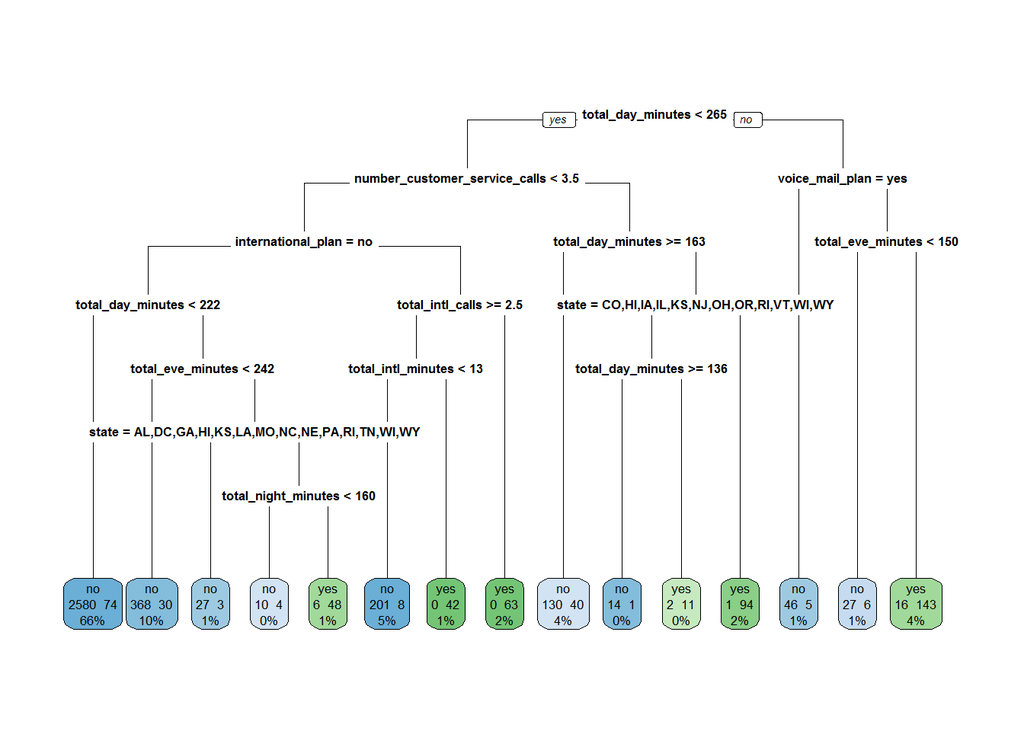

```r
library(rpart)
set.seed(123)
churns_rpart <- rpart(churns_train$churn~., method="class", minsplit = 20,
                      parms = list(split="gini"), data=churns_train)

library(rpart.plot)
rpart.plot(churns_rpart, type=0, extra=101)
```

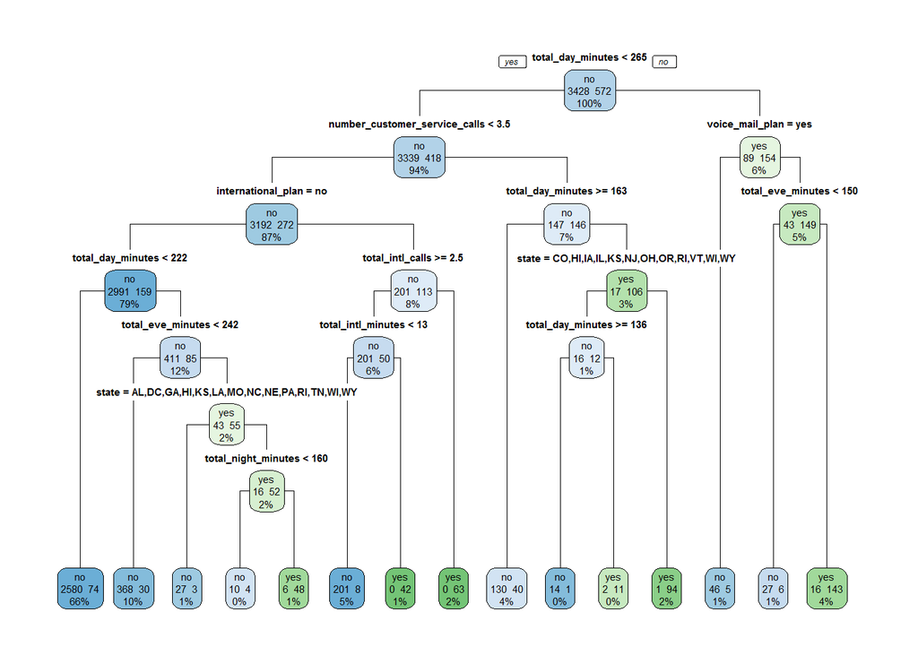

```r
rpart.plot(churns_rpart, type=1, extra=101)
```

```r
#library(party)
#library(partykit)
#plot(as.party(churns_rpart))
```

#### Prune the tree using minimual CP value

```r
cptable<-printcp(churns_rpart)
```

```
##
## Classification tree:
## rpart(formula = churns_train$churn ~ ., data = churns_train,
##     method = "class", parms = list(split = "gini"), minsplit = 20)
##
## Variables actually used in tree construction:
## [1] international_plan            number_customer_service_calls
## [3] state                         total_day_minutes
## [5] total_eve_minutes             total_intl_calls
## [7] total_intl_minutes            total_night_minutes
## [9] voice_mail_plan
##
## Root node error: 572/4000 = 0.143
##
## n= 4000
##
##         CP nsplit rel error  xerror     xstd
## 1 0.113636      0   1.00000 1.00000 0.038707
## 2 0.077797      1   0.88636 0.89510 0.036940
## 3 0.071678      3   0.73077 0.76923 0.034596
## 4 0.055070      4   0.65909 0.69231 0.033023
## 5 0.036713      7   0.47552 0.49301 0.028304
## 6 0.020979      8   0.43881 0.45804 0.027355
## 7 0.011364     11   0.37587 0.43706 0.026765
## 8 0.010490     13   0.35315 0.44580 0.027013
## 9 0.010000     14   0.34266 0.44580 0.027013
```

```r
cptable
```

```
##           CP nsplit rel error    xerror       xstd
## 1 0.11363636      0 1.0000000 1.0000000 0.03870726
## 2 0.07779720      1 0.8863636 0.8951049 0.03694003
## 3 0.07167832      3 0.7307692 0.7692308 0.03459595
## 4 0.05506993      4 0.6590909 0.6923077 0.03302280
## 5 0.03671329      7 0.4755245 0.4930070 0.02830435
## 6 0.02097902      8 0.4388112 0.4580420 0.02735548
## 7 0.01136364     11 0.3758741 0.4370629 0.02676453
## 8 0.01048951     13 0.3531469 0.4458042 0.02701282
## 9 0.01000000     14 0.3426573 0.4458042 0.02701282
```

```r
set.cp.value<-cptable[which.min(cptable[,"xerror"]),"CP"]
set.cp.value
```

```
## [1] 0.01136364
```

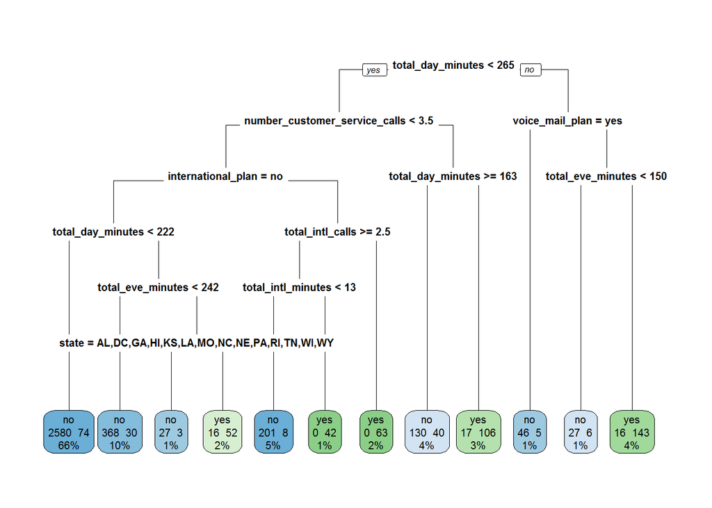

```r
pruned_churns_rpart <- prune(churns_rpart, set.cp.value)
rpart.plot(pruned_churns_rpart, type=0, extra=101)
```

```r
# does not look nice in Knit document
#plot(as.party(pruned_churns_rpart))
```

#### Prune the tree again using meaningflu CP value in cp plot (CP plot slop)

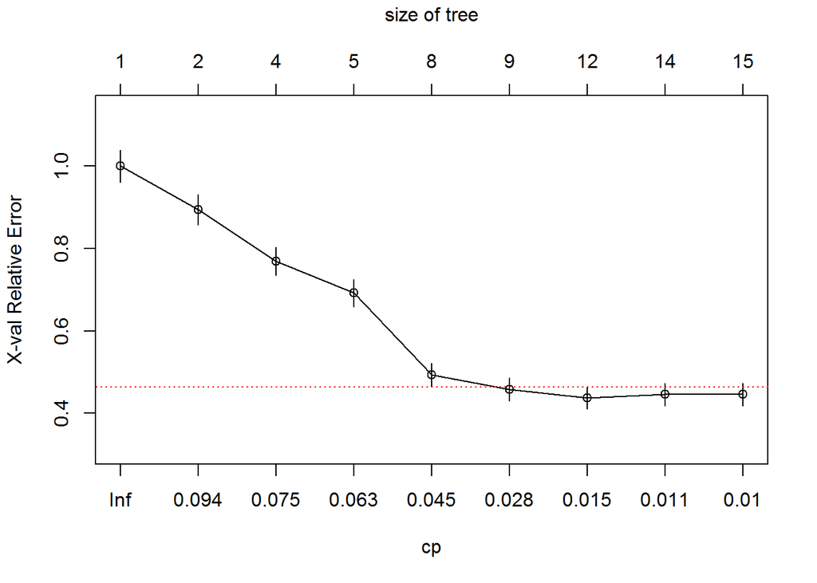

```r
plotcp(churns_rpart, minline=TRUE, col="red")
```

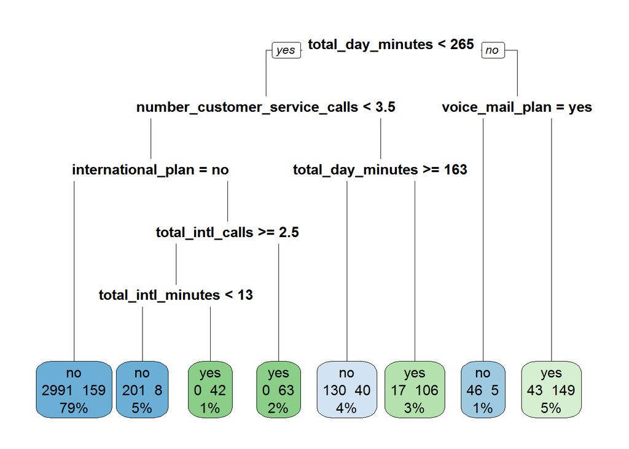

```r
pruned_churns_rpart <- prune(churns_rpart, 0.03671329)
rpart.plot(pruned_churns_rpart, type=0, extra=101)
```

```r
#plot(as.party(pruned_churns_rpart))
```

#### Testing the decision tree using test data

```r
library(caret)
actual <- churns_test$churn
predicted <- predict(pruned_churns_rpart, churns_test, type="class")
results.matrix <- confusionMatrix(predicted, actual, positive="yes")
print(results.matrix)
```

```
## Confusion Matrix and Statistics
##
##           Reference
## Prediction  no yes
##        no  845  47
##        yes  20  88
##
##                Accuracy : 0.933
##                  95% CI : (0.9157, 0.9477)
##     No Information Rate : 0.865
##     P-Value [Acc > NIR] : 0.000000000004861
##
##                   Kappa : 0.6867
##  Mcnemar's Test P-Value : 0.001491
##
##             Sensitivity : 0.6519
##             Specificity : 0.9769
##          Pos Pred Value : 0.8148
##          Neg Pred Value : 0.9473
##              Prevalence : 0.1350
##          Detection Rate : 0.0880
##    Detection Prevalence : 0.1080
##       Balanced Accuracy : 0.8144
##
##        'Positive' Class : yes
##
```

### Method two use information gain

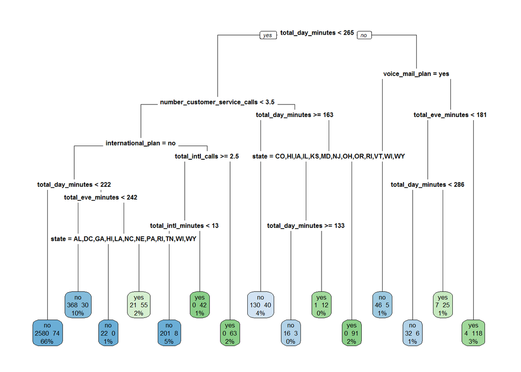

```r
churns_rpart2 <- rpart(churns_train$churn~., method="class", minsplit = 20,
                       parms = list(split="information"), data=churns_train)
rpart.plot(churns_rpart2, type=0, extra=101)
```

####Prune the tree again using meaningflu CP value from CP plot

```r
cptable<-printcp(churns_rpart2)
```

```
##
## Classification tree:
## rpart(formula = churns_train$churn ~ ., data = churns_train,
##     method = "class", parms = list(split = "information"), minsplit = 20)
##
## Variables actually used in tree construction:
## [1] international_plan            number_customer_service_calls
## [3] state                         total_day_minutes
## [5] total_eve_minutes             total_intl_calls
## [7] total_intl_minutes            voice_mail_plan
##
## Root node error: 572/4000 = 0.143
##
## n= 4000
##
##         CP nsplit rel error  xerror     xstd
## 1 0.113636      0   1.00000 1.00000 0.038707
## 2 0.077797      1   0.88636 0.92657 0.037487
## 3 0.071678      3   0.73077 0.79371 0.035073
## 4 0.055070      4   0.65909 0.68881 0.032948
## 5 0.022727      7   0.47552 0.49476 0.028351
## 6 0.019814      9   0.43007 0.47727 0.027883
## 7 0.011364     12   0.37063 0.45629 0.027307
## 8 0.010000     14   0.34790 0.44580 0.027013
```

```r
cptable
```

```
##           CP nsplit rel error    xerror       xstd
## 1 0.11363636      0 1.0000000 1.0000000 0.03870726
## 2 0.07779720      1 0.8863636 0.9265734 0.03748665
## 3 0.07167832      3 0.7307692 0.7937063 0.03507287
## 4 0.05506993      4 0.6590909 0.6888112 0.03294845
## 5 0.02272727      7 0.4755245 0.4947552 0.02835068
## 6 0.01981352      9 0.4300699 0.4772727 0.02788271
## 7 0.01136364     12 0.3706294 0.4562937 0.02730687
## 8 0.01000000     14 0.3479021 0.4458042 0.02701282
```

```r
set.cp.value<-cptable[which.min(cptable[,"xerror"]),"CP"]
set.cp.value
```

```
## [1] 0.01
```

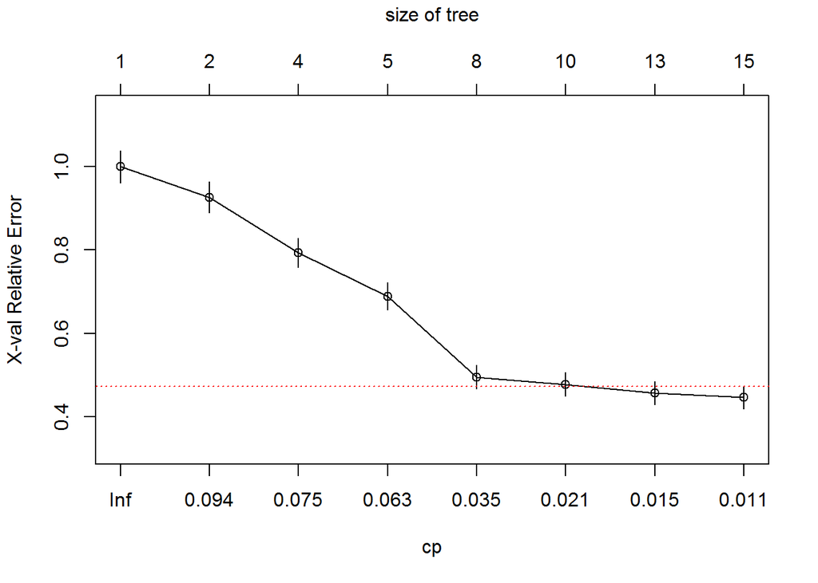

```r
plotcp(churns_rpart2, minline=TRUE, col="red")
```

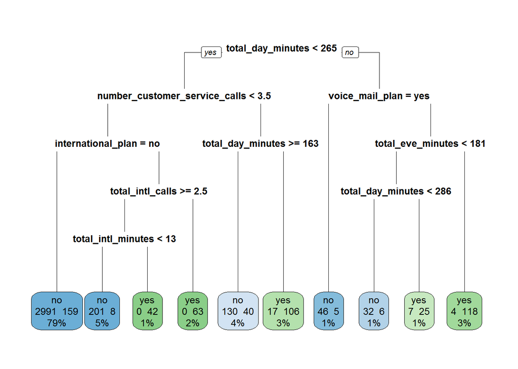

```r
pruned_churns_rpart2 <- prune(churns_rpart2, 0.02272727)
rpart.plot(pruned_churns_rpart2, type=0, extra=101)
```

```r
#plot(as.party(pruned_churns_rpart2))
```

#### Testing the second decision tree using testing data

```r
actual <- churns_test$churn
predicted2 <- predict(pruned_churns_rpart2, churns_test, type="class")
results.matrix2 <- confusionMatrix(predicted2, actual, positive="yes")
print(results.matrix2)
```

```
## Confusion Matrix and Statistics
##
##           Reference
## Prediction  no yes
##        no  852  51
##        yes  13  84
##
##                Accuracy : 0.936
##                  95% CI : (0.919, 0.9504)
##     No Information Rate : 0.865
##     P-Value [Acc > NIR] : 0.0000000000004327
##
##                   Kappa : 0.689
##  Mcnemar's Test P-Value : 0.0000037459840111
##
##             Sensitivity : 0.6222
##             Specificity : 0.9850
##          Pos Pred Value : 0.8660
##          Neg Pred Value : 0.9435
##              Prevalence : 0.1350
##          Detection Rate : 0.0840
##    Detection Prevalence : 0.0970
##       Balanced Accuracy : 0.8036
##
##        'Positive' Class : yes
##
```

### Part B. Customer Churn Again

The PRO sends you an email two days later with a new request. She heard from a data scientist embedded in another department that there is a classification model much simpler than decision trees and can perform just as well (if not better!) in some situations. The model is called k-nearest neighbor (or knn). The PRO asks you to run a knn model and report back its performance. When you told her that you were wrapping up with your memo from her previous request, she told you there is no need to write a new memo. You can just add an “addendum” section to your existing memorandum.

#### Randomize data and change categorical variables to numeric 1 and 0

```r
set.seed(123)
churns_rand <- churns[order(runif(5000)), ]
churns_rand$international_plan_yes <-ifelse(churns_rand$international_plan=="yes",1,0)
churns_rand$international_plan <- NULL

churns_rand$voice_mail_plan_yes <-ifelse(churns_rand$voice_mail_plan=="yes",1,0)
churns_rand$voice_mail_plan <- NULL

churns_rand$state <- NULL
churns_rand$area_code <- NULL

str(churns_rand)
```

```
## 'data.frame':    5000 obs. of  18 variables:
##  $ account_length               : int  91 97 12 98 134 16 79 141 99 64 ...
##  $ number_vmail_messages        : int  0 0 0 19 0 0 0 33 28 22 ...
##  $ total_day_minutes            : num  153 230.6 239.7 110.5 7.8 ...
##  $ total_day_calls              : int  123 131 112 87 86 91 124 127 88 80 ...
##  $ total_day_charge             : num  26.01 39.2 40.75 18.79 1.33 ...
##  $ total_eve_minutes            : num  141 261 221 228 171 ...
##  $ total_eve_calls              : int  127 136 122 97 100 75 91 106 116 84 ...
##  $ total_eve_charge             : num  12 22.2 18.8 19.4 14.6 ...
##  $ total_night_minutes          : num  172 157 207 244 186 ...
##  $ total_night_calls            : int  76 96 109 84 80 73 110 78 102 67 ...
##  $ total_night_charge           : num  7.72 7.07 9.33 10.96 8.39 ...
##  $ total_intl_minutes           : num  10.3 6.8 11.1 11 12.9 6.4 15.1 11 9.1 7.6 ...
##  $ total_intl_calls             : int  15 4 3 4 2 7 2 4 5 5 ...
##  $ total_intl_charge            : num  2.78 1.84 3 2.97 3.48 1.73 4.08 2.97 2.46 2.05 ...
##  $ number_customer_service_calls: int  1 0 2 1 2 0 1 2 1 1 ...
##  $ churn                        : Factor w/ 2 levels "no","yes": 2 1 1 1 1 1 1 1 1 1 ...
##  $ international_plan_yes       : num  0 1 0 0 0 1 0 0 0 0 ...
##  $ voice_mail_plan_yes          : num  0 0 0 1 0 0 0 1 1 1 ...
```

```r
churns_rand<-churns_rand[, c(16,1:15,17:18)] #Rearranging the columns so that our target variable is first
str(churns_rand)
```

```
## 'data.frame':    5000 obs. of  18 variables:
##  $ churn                        : Factor w/ 2 levels "no","yes": 2 1 1 1 1 1 1 1 1 1 ...
##  $ account_length               : int  91 97 12 98 134 16 79 141 99 64 ...
##  $ number_vmail_messages        : int  0 0 0 19 0 0 0 33 28 22 ...
##  $ total_day_minutes            : num  153 230.6 239.7 110.5 7.8 ...
##  $ total_day_calls              : int  123 131 112 87 86 91 124 127 88 80 ...
##  $ total_day_charge             : num  26.01 39.2 40.75 18.79 1.33 ...
##  $ total_eve_minutes            : num  141 261 221 228 171 ...
##  $ total_eve_calls              : int  127 136 122 97 100 75 91 106 116 84 ...
##  $ total_eve_charge             : num  12 22.2 18.8 19.4 14.6 ...
##  $ total_night_minutes          : num  172 157 207 244 186 ...
##  $ total_night_calls            : int  76 96 109 84 80 73 110 78 102 67 ...
##  $ total_night_charge           : num  7.72 7.07 9.33 10.96 8.39 ...
##  $ total_intl_minutes           : num  10.3 6.8 11.1 11 12.9 6.4 15.1 11 9.1 7.6 ...
##  $ total_intl_calls             : int  15 4 3 4 2 7 2 4 5 5 ...
##  $ total_intl_charge            : num  2.78 1.84 3 2.97 3.48 1.73 4.08 2.97 2.46 2.05 ...
##  $ number_customer_service_calls: int  1 0 2 1 2 0 1 2 1 1 ...
##  $ international_plan_yes       : num  0 1 0 0 0 1 0 0 0 0 ...
##  $ voice_mail_plan_yes          : num  0 0 0 1 0 0 0 1 1 1 ...
```

#### Normalize data to Z-scale and separate to training set and testing set

```r
# z scale
churns_rand_z <- as.data.frame(scale(churns_rand[-1]))
str(churns_rand_z)
```

```
## 'data.frame':    5000 obs. of  17 variables:
##  $ account_length               : num  -0.2332 -0.0821 -2.2234 -0.0569 0.85 ...
##  $ number_vmail_messages        : num  -0.572 -0.572 -0.572 0.83 -0.572 ...
##  $ total_day_minutes            : num  -0.506 0.934 1.102 -1.295 -3.2 ...
##  $ total_day_calls              : num  1.158 1.562 0.604 -0.657 -0.707 ...
##  $ total_day_charge             : num  -0.506 0.933 1.102 -1.294 -3.2 ...
##  $ total_eve_minutes            : num  -1.178 1.2 0.405 0.537 -0.578 ...
##  $ total_eve_calls              : num  1.35218 1.80612 1.09999 -0.16095 -0.00963 ...
##  $ total_eve_charge             : num  -1.179 1.2 0.404 0.537 -0.578 ...
##  $ total_night_minutes          : num  -0.572 -0.857 0.137 0.855 -0.275 ...
##  $ total_night_calls            : num  -1.198 -0.196 0.455 -0.798 -0.998 ...
##  $ total_night_charge           : num  -0.571 -0.857 0.137 0.854 -0.276 ...
##  $ total_intl_minutes           : num  0.0138 -1.2536 0.3035 0.2673 0.9554 ...
##  $ total_intl_calls             : num  4.3 -0.177 -0.584 -0.177 -0.991 ...
##  $ total_intl_charge            : num  0.0118 -1.2491 0.3069 0.2667 0.9508 ...
##  $ number_customer_service_calls: num  -0.437 -1.202 0.329 -0.437 0.329 ...
##  $ international_plan_yes       : num  -0.323 3.093 -0.323 -0.323 -0.323 ...
##  $ voice_mail_plan_yes          : num  -0.6 -0.6 -0.6 1.67 -0.6 ...
```

```r
churns_train_z <- churns_rand_z[1:4000,]
churns_test_z <- churns_rand_z[4001:5000,]

churns_train_labels<-churns_rand[1:4000,1]
churns_test_labels<-churns_rand[4001:5000,1]
```

#### Run KNN model K = 63

```r
num_of_k <- sqrt(4000)
num_of_k
```

```
## [1] 63.24555
```

```r
library(class)
library(gmodels)
churns_pred <- knn(train=churns_train_z, test=churns_test_z, cl=churns_train_labels, k=63)
CrossTable(x=churns_pred, y=churns_test_labels, prop.chisq = FALSE)
```

```
##
##
##    Cell Contents
## |-------------------------|
## |                       N |
## |           N / Row Total |
## |           N / Col Total |
## |         N / Table Total |
## |-------------------------|
##
##
## Total Observations in Table:  1000
##
##
##              | churns_test_labels
##  churns_pred |        no |       yes | Row Total |
## -------------|-----------|-----------|-----------|
##           no |       865 |       116 |       981 |
##              |     0.882 |     0.118 |     0.981 |
##              |     1.000 |     0.859 |           |
##              |     0.865 |     0.116 |           |
## -------------|-----------|-----------|-----------|
##          yes |         0 |        19 |        19 |
##              |     0.000 |     1.000 |     0.019 |
##              |     0.000 |     0.141 |           |
##              |     0.000 |     0.019 |           |
## -------------|-----------|-----------|-----------|
## Column Total |       865 |       135 |      1000 |
##              |     0.865 |     0.135 |           |
## -------------|-----------|-----------|-----------|
##
##
```

#### Testing model on testing data set

```r
TP = 19
TN = 865
FP = 0
FN = 116
Sensitivity = TP/(TP+FN) #true positive rate; recall; TP/(TP+FN)
Specificity = TN/(TN+FP) #how often is the prediction negative when actual is negative?
Precision = TP/(TP+FP) #how often is prediction positive when actual is positive?
Accuracy = (TP+TN)/(TP+TN+FP+FN) #how often is classifier correct

Value<-round(c(TP,TN,FP,FN,Sensitivity,Specificity,Precision,Accuracy),digits=3)
Measure<-c("True Positive","True Negative","False Positive","False Negative","Sensitivity/Recall=TP/(TN+FP)",
           "Specificity=TN/(TN+TP)","Precision=TP/(TP+FP)","Accuracy=(TP+TN)/total")

table<-as.data.frame(cbind(Measure,Value))

library(knitr)
kable(table)
```

| Measure | Value |
| --- | --- |
| True Positive | 19 |
| True Negative | 865 |
| False Positive | 0 |
| False Negative | 116 |
| Sensitivity/Recall=TP/(TN+FP) | 0.141 |
| Specificity=TN/(TN+TP) | 1 |
| Precision=TP/(TP+FP) | 1 |
| Accuracy=(TP+TN)/total | 0.884 |

### Bonus Point: Create a KNN model from variables in Decision Tree

#### KNN model 2 use variables and criteria from Decision Tree 1

```r
set.seed(123)
churns_rand <- churns[order(runif(5000)), ]
churns_knn<- churns_rand[,c(20,7,19,4,17,16,7,5)]
#str(churns_knn)

# change to factor
churns_knn$total_day_minutes_large<-ifelse(churns_knn$total_day_minutes<264.75,0,1)
churns_knn$number_customer_service_calls_large<-ifelse(churns_knn$number_customer_service_calls<3.5,0,1)
churns_knn$total_intl_calls_large<-ifelse(churns_knn$total_intl_calls<2.5,0,1)
churns_knn$total_intl_minutes_large<-ifelse(churns_knn$total_intl_minutes<13.1,0,1)
churns_knn$international_plan_yes <-ifelse(churns_knn$international_plan=="yes",1,0)
churns_knn$total_day_minutes.1_large<-ifelse(churns_knn$total_day_minutes.1<163.5,0,1)
churns_knn$voice_mail_plan_yes <-ifelse(churns_knn$voice_mail_plan=="yes",1,0)


churns_knn$total_day_minutes <- NULL
churns_knn$number_customer_service_calls <- NULL
churns_knn$total_intl_calls <- NULL
churns_knn$total_intl_minutes <- NULL
churns_knn$total_day_minutes <- NULL
churns_knn$total_day_minutes.1 <- NULL
churns_knn$international_plan <- NULL
churns_knn$voice_mail_plan <- NULL

str(churns_knn)
```

```
## 'data.frame':    5000 obs. of  8 variables:
##  $ churn                              : Factor w/ 2 levels "no","yes": 2 1 1 1 1 1 1 1 1 1 ...
##  $ total_day_minutes_large            : num  0 0 0 0 0 0 0 0 0 0 ...
##  $ number_customer_service_calls_large: num  0 0 0 0 0 0 0 0 0 0 ...
##  $ total_intl_calls_large             : num  1 1 1 1 0 1 0 1 1 1 ...
##  $ total_intl_minutes_large           : num  0 0 0 0 0 0 1 0 0 0 ...
##  $ international_plan_yes             : num  0 1 0 0 0 1 0 0 0 0 ...
##  $ total_day_minutes.1_large          : num  0 1 1 0 0 0 0 1 1 1 ...
##  $ voice_mail_plan_yes                : num  0 0 0 1 0 0 0 1 1 1 ...
```

#### Normalize data to Z-scale and separate to training set and testing data set

```r
churns_knn_z <- as.data.frame(scale(churns_knn[-1]))

churns_knn_train_z <- churns_knn_z[1:4000,]
churns_knn_test_z <- churns_knn_z[4001:5000,]

churns_train_labels <- churns_knn[1:4000,1]
churns_test_labels <- churns_knn[4001:5000,1]
```

#### Create the second KNN model K = 63

```r
num_of_knn <- sqrt(4000)
num_of_knn
```

```
## [1] 63.24555
```

```r
library(class)
library(gmodels)
set.seed(123)
churns_knn_z_pred <- knn(train=churns_knn_train_z, test=churns_knn_test_z, cl=churns_train_labels, k=63)
CrossTable(x=churns_knn_z_pred, y=churns_test_labels, prop.chisq = FALSE)
```

```
##
##
##    Cell Contents
## |-------------------------|
## |                       N |
## |           N / Row Total |
## |           N / Col Total |
## |         N / Table Total |
## |-------------------------|
##
##
## Total Observations in Table:  1000
##
##
##                   | churns_test_labels
## churns_knn_z_pred |        no |       yes | Row Total |
## ------------------|-----------|-----------|-----------|
##                no |       825 |        73 |       898 |
##                   |     0.919 |     0.081 |     0.898 |
##                   |     0.954 |     0.541 |           |
##                   |     0.825 |     0.073 |           |
## ------------------|-----------|-----------|-----------|
##               yes |        40 |        62 |       102 |
##                   |     0.392 |     0.608 |     0.102 |
##                   |     0.046 |     0.459 |           |
##                   |     0.040 |     0.062 |           |
## ------------------|-----------|-----------|-----------|
##      Column Total |       865 |       135 |      1000 |
##                   |     0.865 |     0.135 |           |
## ------------------|-----------|-----------|-----------|
##
##
```

#### Testing the model using testing data set

```r
TP = 62
TN = 825
FP = 40
FN = 73
Sensitivity = TP/(TP+FN) #true positive rate; recall; TP/(TP+FN)
Specificity = TN/(TN+FP) #how often is the prediction negative when actual is negative?
Precision = TP/(TP+FP) #how often is prediction positive when actual is positive?
Accuracy = (TP+TN)/(TP+TN+FP+FN) #how often is classifier correct

Value<-round(c(TP,TN,FP,FN,Sensitivity,Specificity,Precision,Accuracy),digits=3)
Measure<-c("True Positive","True Negative","False Positive","False Negative","Sensitivity/Recall=TP/(TN+FP)",
           "Specificity=TN/(TN+TP)","Precision=TP/(TP+FP)","Accuracy=(TP+TN)/total")

table<-as.data.frame(cbind(Measure,Value))

library(knitr)
kable(table)
```

| Measure | Value |
| --- | --- |
| True Positive | 62 |
| True Negative | 825 |
| False Positive | 40 |
| False Negative | 73 |
| Sensitivity/Recall=TP/(TN+FP) | 0.459 |
| Specificity=TN/(TN+TP) | 0.954 |
| Precision=TP/(TP+FP) | 0.608 |
| Accuracy=(TP+TN)/total | 0.887 |

### Part C. Customer Churn One Last Time

The PRO sends you yet another email two days later. She has some concerns that the Board will want to know that “tried and true regression methods” have been considered. She asks for another addendum to show the results from a regression model as well.

#### Bonus Point: pick variables and qualifications from Decision Tree.

```r
set.seed(123) #set a seed to do draws from a random uniform distribution.
churns_rand <- churns[order(runif(5000)), ]
churns_logit<- churns_rand[,c(20,7,19,4,17,16,5)]
#str(churns_logit)

churns_logit$total_day_minutes_large<-ifelse(churns_logit$total_day_minutes<264.75,"no","yes")
churns_logit$number_customer_service_calls_large<-ifelse(churns_logit$number_customer_service_calls<3.5,"no","yes")
churns_logit$total_intl_calls_large<-ifelse(churns_logit$total_intl_calls<2.5,"no","yes")
churns_logit$total_intl_minutes_large<-ifelse(churns_logit$total_intl_minutes<13.1,"no","yes")

churns_logit$total_day_minutes <- NULL
churns_logit$number_customer_service_calls <- NULL
churns_logit$total_intl_calls <- NULL
churns_logit$total_intl_minutes <- NULL

str(churns_logit)
```

```
## 'data.frame':    5000 obs. of  7 variables:
##  $ churn                              : Factor w/ 2 levels "no","yes": 2 1 1 1 1 1 1 1 1 1 ...
##  $ international_plan                 : Factor w/ 2 levels "no","yes": 1 2 1 1 1 2 1 1 1 1 ...
##  $ voice_mail_plan                    : Factor w/ 2 levels "no","yes": 1 1 1 2 1 1 1 2 2 2 ...
##  $ total_day_minutes_large            : chr  "no" "no" "no" "no" ...
##  $ number_customer_service_calls_large: chr  "no" "no" "no" "no" ...
##  $ total_intl_calls_large             : chr  "yes" "yes" "yes" "yes" ...
##  $ total_intl_minutes_large           : chr  "no" "no" "no" "no" ...
```

#### Separate data into training and testing data set then run Logistic Regression.

```r
churns_train_logit <- churns_logit[1:4000, ] #Training data set; 4000 rows
churns_test_logit  <-churns_logit[4001:5000, ] #Testing data set; 1000 rows

churnLogitModel <- glm(churn~., data=churns_train_logit, family=binomial()) #Fit a logistic regression
summary(churnLogitModel) #coefficients are presented as log-odds (probabilities on logit scale)
```

```
##
## Call:
## glm(formula = churn ~ ., family = binomial(), data = churns_train_logit)
##
## Deviance Residuals:
##     Min       1Q   Median       3Q      Max
## -3.2203  -0.4390  -0.3127  -0.1858   2.8523
##
## Coefficients:
##                                        Estimate Std. Error z value
## (Intercept)                             -2.1672     0.1173 -18.476
## international_planyes                    2.2090     0.1417  15.589
## voice_mail_planyes                      -1.0566     0.1467  -7.201
## total_day_minutes_largeyes               3.1859     0.1654  19.256
## number_customer_service_calls_largeyes   2.7787     0.1474  18.850
## total_intl_calls_largeyes               -0.8267     0.1244  -6.643
## total_intl_minutes_largeyes              0.7026     0.1389   5.059
##                                                    Pr(>|z|)
## (Intercept)                            < 0.0000000000000002 ***
## international_planyes                  < 0.0000000000000002 ***
## voice_mail_planyes                        0.000000000000596 ***
## total_day_minutes_largeyes             < 0.0000000000000002 ***
## number_customer_service_calls_largeyes < 0.0000000000000002 ***
## total_intl_calls_largeyes                 0.000000000030658 ***
## total_intl_minutes_largeyes               0.000000421487003 ***
## ---
## Signif. codes:  0 '***' 0.001 '**' 0.01 '*' 0.05 '.' 0.1 ' ' 1
##
## (Dispersion parameter for binomial family taken to be 1)
##
##     Null deviance: 3283.0  on 3999  degrees of freedom
## Residual deviance: 2303.1  on 3993  degrees of freedom
## AIC: 2317.1
##
## Number of Fisher Scoring iterations: 6
```

```r
exp(cbind(Odds_Ratio=coef(churnLogitModel))) #Take exponent of log odds gives "odds" ratio.
```

```
##                                        Odds_Ratio
## (Intercept)                             0.1145008
## international_planyes                   9.1062617
## voice_mail_planyes                      0.3476362
## total_day_minutes_largeyes             24.1886104
## number_customer_service_calls_largeyes 16.0980895
## total_intl_calls_largeyes               0.4375066
## total_intl_minutes_largeyes             2.0190187
```

#### Analysis of Variance on the model.

```r
anova(churnLogitModel,test="Chisq")
```

```
## Analysis of Deviance Table
##
## Model: binomial, link: logit
##
## Response: churn
##
## Terms added sequentially (first to last)
##
##
##                                     Df Deviance Resid. Df Resid. Dev
## NULL                                                 3999     3283.0
## international_plan                   1   182.54      3998     3100.4
## voice_mail_plan                      1    51.92      3997     3048.5
## total_day_minutes_large              1   343.75      3996     2704.8
## number_customer_service_calls_large  1   336.21      3995     2368.6
## total_intl_calls_large               1    41.08      3994     2327.5
## total_intl_minutes_large             1    24.35      3993     2303.1
##                                                  Pr(>Chi)
## NULL
## international_plan                  < 0.00000000000000022 ***
## voice_mail_plan                        0.0000000000005779 ***
## total_day_minutes_large             < 0.00000000000000022 ***
## number_customer_service_calls_large < 0.00000000000000022 ***
## total_intl_calls_large                 0.0000000001458189 ***
## total_intl_minutes_large               0.0000008030306467 ***
## ---
## Signif. codes:  0 '***' 0.001 '**' 0.01 '*' 0.05 '.' 0.1 ' ' 1
```

#### Use the model on testing data.

```r
churns_test_logit$predictChurnLogit<-predict(churnLogitModel, newdata=churns_test_logit)
odds <- exp(churns_test_logit$predictChurnLogit)
churns_test_logit$PredictedProb <- data.frame(odds/(1+odds))
library(psych)
# predicted 15% churn vs actual 13.5% churn
describe(churns_test_logit$PredictedProb)
```

```
##                 vars    n mean   sd median trimmed  mad  min  max range
## odds..1...odds.    1 1000 0.15 0.21   0.05     0.1 0.05 0.02 0.99  0.97
##                 skew kurtosis   se
## odds..1...odds. 2.08     3.71 0.01
```

```r
FREQ_TABLE<-table(churns_test_logit$churn)
PROB_TABLE<-prop.table(FREQ_TABLE)
PROB_TABLE
```

```
##
##    no   yes
## 0.865 0.135
```

```r
churns_test_logit$predictChurnLogit<-NULL
churns_test_logit$PredictedProb<-NULL
```

#### Confidence interval on fitted churn probability.

```r
churns_test_logit_CI<-cbind(churns_test_logit, predict(churnLogitModel, newdata=churns_test_logit, type="link", se=TRUE))
churns_test_logit_CI <- within(churns_test_logit_CI,
                                    {
                                      PredictedProb <- plogis(fit)
                                      LL <- plogis(fit - (1.96 * se.fit))
                                      UL <- plogis(fit + (1.96 * se.fit))
                                    })
churns_test_logit_CI.predictedChurn <- rep("no" ,1000)
churns_test_logit_CI.predictedChurn[churns_test_logit_CI$PredictedProb >.5] <- "yes"
#table(churns_test_logit_CI.predictedChurn, churns_test_logit_CI$churn)
CrossTable(x=churns_test_logit_CI.predictedChurn, y=churns_test_logit_CI$churn, prop.chisq = FALSE)
```

```
##
##
##    Cell Contents
## |-------------------------|
## |                       N |
## |           N / Row Total |
## |           N / Col Total |
## |         N / Table Total |
## |-------------------------|
##
##
## Total Observations in Table:  1000
##
##
##                                     | churns_test_logit_CI$churn
## churns_test_logit_CI.predictedChurn |        no |       yes | Row Total |
## ------------------------------------|-----------|-----------|-----------|
##                                  no |       837 |        77 |       914 |
##                                     |     0.916 |     0.084 |     0.914 |
##                                     |     0.968 |     0.570 |           |
##                                     |     0.837 |     0.077 |           |
## ------------------------------------|-----------|-----------|-----------|
##                                 yes |        28 |        58 |        86 |
##                                     |     0.326 |     0.674 |     0.086 |
##                                     |     0.032 |     0.430 |           |
##                                     |     0.028 |     0.058 |           |
## ------------------------------------|-----------|-----------|-----------|
##                        Column Total |       865 |       135 |      1000 |
##                                     |     0.865 |     0.135 |           |
## ------------------------------------|-----------|-----------|-----------|
##
##
```

```r
TP = 58
TN = 837
FP = 28
FN = 77
Sensitivity = TP/(TP+FN) #true positive rate; recall; TP/(TP+FN)
Specificity = TN/(TN+FP) #how often is the prediction negative when actual is negative?
Precision = TP/(TP+FP) #how often is prediction positive when actual is positive?
Accuracy = (TP+TN)/(TP+TN+FP+FN) #how often is classifier correct

Value<-round(c(TP,TN,FP,FN,Sensitivity,Specificity,Precision,Accuracy),digits=3)
Measure<-c("True Positive","True Negative","False Positive","False Negative","Sensitivity/Recall=TP/(TN+FP)",
           "Specificity=TN/(TN+TP)","Precision=TP/(TP+FP)","Accuracy=(TP+TN)/total")

table<-as.data.frame(cbind(Measure,Value))

library(knitr)
kable(table)
```

| Measure | Value |
| --- | --- |
| True Positive | 58 |
| True Negative | 837 |
| False Positive | 28 |
| False Negative | 77 |
| Sensitivity/Recall=TP/(TN+FP) | 0.43 |
| Specificity=TN/(TN+TP) | 0.968 |
| Precision=TP/(TP+FP) | 0.674 |
| Accuracy=(TP+TN)/total | 0.895 |

END